# Session 6 notes, 2018-10-29

Plan:

**Revision** Consolodate visualisation skills by going over homework solutions

**New** Explore ways to summarise numerical data

# Some simple statistics

- Characterising a sample
  - range
  - mean
  - median
- Variance and standard deviation
  - sd
- Distributions and histograms
  - rnorm
  - runif

### Revision: some less familiar operators

Integer division: `%/%`

- This gives you the whole number part of a division

```r
7 %/% 2
```

```
[1] 3
```

You can do this with a series of numerals

```r
1:10 %/% 3
```

```
 [1] 0 0 1 1 1 2 2 2 3 3
```

Modulo `%%`:

- This gives you the remainder after you’ve done division.

```r
17 %/% 3
```

```
[1] 5
```

```r
17 %% 3
```

```
[1] 2
```

This is often used to tell if a number is even or odd:

```r
#numbers <- 1:10
numbers <- c(4,45,2,46,96,75,32)
numbers %% 2
```

```
[1] 0 1 0 0 0 1 0
```

```r
numbers %% 2 == 1
```

```
[1] FALSE  TRUE FALSE FALSE FALSE  TRUE FALSE
```

Selecting the odd numbers

```r
numbers[numbers %% 2 == 1]
```

```
[1] 45 75
```

Selecting the even numbers

```r
numbers[numbers %% 2 == 0]
```

```
[1]  4  2 46 96 32
```

**NOTE** that this only works for integers (whole numbers); R often works with `numeric` values, which can also be decimals.

- cf. the `is.integer()` and `as.integer()` functions

## Mean

We’ll look at this again later, but here’s a reminder about the `runif()` function to generate random numbers

```r
runif(10) # by default from 0 to 1
```

```
 [1] 0.3561 0.8718 0.1580 0.7354 0.9886 0.6004 0.7171 0.9770 0.4326 0.7649
```

```r
runif(10, 0, 100) # or specify min max
```

```
 [1] 82.735  8.145 84.839  8.281  8.890  9.847 54.866 13.696 51.634 77.782
```

```r
as.integer(runif(10,0,100))
```

```
 [1]  1 42 62 31 35 84 84 52 90 31
```

- Make a function to calculate the mean
  - needs `sum` and `length`

```r
values <- runif(30, 17, 987)
```

```r
sum(values) / length(values)
```

```
[1] 490.3
```

```r
# my_func <- function(arg1) {do something with arg1}
custom.mean.func <- function(v) { sum(v)/length(v)}
```

```r
custom.mean.func(values)
```

```
[1] 490.3
```

```r
custom.mean.func(1:10)
```

```
[1] 5.5
```

```r
mean(values) ## the built-in function
```

```
[1] 490.3
```

- Although there is actually a `mean()` function that does exactly what you’d expect
- Handling NAs

```r
values[3] <- NA
values
```

```
 [1] 295.28  21.33     NA 243.24 720.07 963.24 494.86 432.98 841.42 801.84 946.57 748.44  92.99 392.27 960.72 423.76 409.10 299.33 839.03  48.92 282.76
[22] 128.44 315.35 496.87 773.54 101.12 652.96 193.01 492.19 412.95
```

```r
mean(values)
```

```
[1] NA
```

```r
mean(values, na.rm=TRUE)
```

```
[1] 476.7
```

```r
custom.mean.func <- function(v, na.rm=FALSE) {
  sum(v, na.rm=na.rm)/length(v[!is.na(v)])}
custom.mean.func(values, na.rm=TRUE)
```

```
[1] 476.7
```

## Median

The middle value of a sorted series; if there are an even number of values then take the value halfway between the middle two.

```r
values <- runif(21, 1, 55)
mean(values)
```

```
[1] 26.62
```

```r
median(values)
```

```
[1] 23.72
```

```r
# sort the values
sort(values)
```

```
 [1]  2.002  4.365  7.692 11.380 13.674 15.092 16.171 17.316 21.775 21.977 23.724 25.052 27.305 31.939 36.334 41.505 43.295 44.519 45.651 53.712 54.597
```

```r
# the index for the midpoint is integer-half plus one
(length(values) %/% 2) + 1
```

```
[1] 11
```

```r
# use this number to index the sorted vector
sort(values)[11]
```

```
[1] 23.72
```

```r
# put it all together
sort(values)[(length(values) %/% 2) + 1]
```

```
[1] 23.72
```

```r
odd.median <- function(v) {sort(v)[(length(v) %/% 2) + 1]}
# some tests
values <- runif(101, 0, 10)
odd.median(values)
```

```
[1] 4.927
```

```r
median(values)
```

```
[1] 4.927
```

```r
values <- runif(100, 0, 10)
odd.median(values)
```

```
[1] 5.355
```

```r
median(values)
```

```
[1] 5.3
```

```r
even.median <- function(v){
  v.1 = sort(v)[length(v) %/% 2]
  v.2 = sort(v)[(length(v) %/% 2) + 1]
  (v.1 + v.2) / 2
}
even.median(values)
```

```
[1] 5.3
```

```r
median(values)
```

```
[1] 5.3
```

```r
universal.median <- function(v){
  if (length(v) %% 2 == 1) { ## ODD
    sort(v)[(length(v) %/% 2) + 1]
  } else { ## EVEN
    v.1 = sort(v)[length(v) %/% 2]
    v.2 = sort(v)[(length(v) %/% 2) + 1]
    (v.1 + v.2) / 2
  }
}
```

Let’s run some tests

```r
library(testthat)
for (i in 10:20){
  values <- runif(i, 0, 100)
  #print(universal.median(values) == median(values))
  expect_equal(universal.median(values), median(values))
}
```

- Make your own function to calculate the median
  - `sort` function
  - `%%` and `%/%` (to carry out calculations over the indexes of the vector)
- Compare the output of your function to the built-in `median` function using the `testthat` package
- When is mean useful and when is median useful

```r
income <- runif(100, 1000, 1500)
mean(income)
```

```
[1] 1264
```

```r
median(income)
```

```
[1] 1263
```

But now someone really wealthy joins

```r
income.2 <- c(income, 1000000)
mean(income.2)
```

```
[1] 11153
```

```r
median(income.2)
```

```
[1] 1264
```

## Range

Knowing the range of a set of numbers can be useful

- min
- max
- range

Test these all out

```r
values <- runif(10, 0, 100)
min(values)
```

```
[1] 8.117
```

```r
max(values)
```

```
[1] 87.95
```

```r
range(values)
```

```
[1]  8.117 87.952
```

Problem: doesn’t handle outliers well Solution: look at the variance

## Population variance

The following shows how much each of these values differs from the mean value

```r
values
```

```
 [1] 58.553 66.401 53.200 78.226 39.967 49.443 10.270 87.952  8.117 63.363
```

```r
values - mean(values)
```

```
 [1]   7.004  14.851   1.651  26.677 -11.583  -2.106 -41.279  36.402 -43.432  11.814
```

Problem if we want the average difference from the mean, since some are positive and some are negative:

```r
sum(values - mean(values))
```

```
[1] 0
```

Solution is to square the values (in addition this has the generally desirable side effect of emphasising the larger values over the smaller values)

```r
values - mean(values)
```

```
 [1]   7.004  14.851   1.651  26.677 -11.583  -2.106 -41.279  36.402 -43.432  11.814
```

```r
(values - mean(values))^2
```

```
 [1]   49.056  220.567    2.726  711.661  134.156    4.437 1703.935 1325.135 1886.363  139.574
```

```r
# The average square of the difference from the mean
sum((values - mean(values))^2) / length(a.c)
```

[output not shown]

The average square of the difference from the mean is called the *population variance*

**This assumes that we are working with population, not a sample.** The population is everything, the sample is a random subset.

Summary

- $\mu$ is the population mean (can be difficult or impossible to know)
- We could look at how much each value differs from the mean:

The average of this would be a nice statement of how far off the mean the values tend to be:
$$\frac{\Sigma(x_i - \mu)}{N}$$
But there’s a problem, because these add up to zero

i.e. zero (sometimes this will give an extremely small number instead of zero — the precision of a computer is **less** than your human precision since the computer has to convert all these values to binary)

The solution: square it
$$\sigma^2 = \frac{\Sigma(x_i - \mu)^2}{N}$$

- Guaranteed positive values
- Big differences from the mean are more heavily weighted than small differences
- Note $\sigma^2$ is the symbol for *population variance*

## Sample variance

- var

What if we don’t know the true mean? If we have a sample of the members of the population rather than the whole population.

- We use the sample mean rather than true mean in the equation
- We replace N by N - 1 (mathematical proof is hard, but basicially: the sample mean is always closer to the middle of the sample than the true mean, so using the population variance formula on a sample *underestimates* the value of the variance. Dividing by N-1 rather than by N *increases* the estimate of the variance slightly to compensate for this)

$$s^2 = \frac{\Sigma(x_i - \bar{x})^2}{N - 1}$$

- The symbol for *sample variance* is $s^2$
- The r function `var()` can be used to calculate the sample variance

## Standard deviation (population and sample)

- sd

Variance is kind of abstract

The solution is simply to take the square root. This is called the *standard deviation*

Usually we use the *sample standard deviation*:
$$s = \sqrt{\frac{\Sigma(x_i - \bar{x})^2}{N - 1}}$$

There is also a *population standard deviation*, for when you are working with *all* the values that exist:
$$\sigma = \sqrt{\frac{\Sigma(x_i - \mu)^2}{N}}$$
- The r function `sd()` calculates the *sample standard deviation* (see `help(sd)`) - Just for practice, make your own function to calculate sample standard deviation and compare it to the built-in function (using `testthat` package) - Make a function to calculate population standard devation and compare the values to sample standard deviation

## Normal distribution

Galton Board

[video not shown]

In a normal distribution: - 68.2% of values within one standard deviation - 95.4% within two standard deviations - 99.7% within 3 - 99.99% within 4

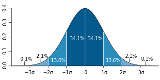

Standard deviations

Normal distributions can be described by two parameters, mean and standard deviation. The `rnorm()` function generates vectors of random numbers accordingn to a normal distribution.

- Read the help for the `rnorm()` function. Generate some vectors of normally distributed random numbers given different means and standard deviations.
- Graph them and work out their means and standard deviations from the vectors

## Histogram

- rnorm(N, mean, sd)

## Uniform distribution

There are many kinds of distributions.

- runif(N, min, max)

In the *Uniform distribution* there is an equal chance of getting any value between the minimum and the maximum

# HOMEWORK NOTES

```r
library(babynames)
library(stringr)
```

Anna’s name plot compares four dimensions (year, popularity, name, sex)

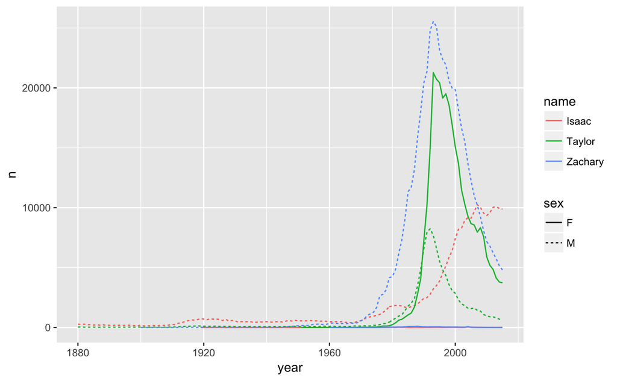

```r
babynames%>%
  filter(name=="Taylor"|name=="Zachary"|name=="Isaac")%>%
  ggplot(aes(x=year, y=n, colour=name, linetype=sex)) + geom_line()
```

Plotting mean name length of boys and girls (adapted from Bror-Magnus)

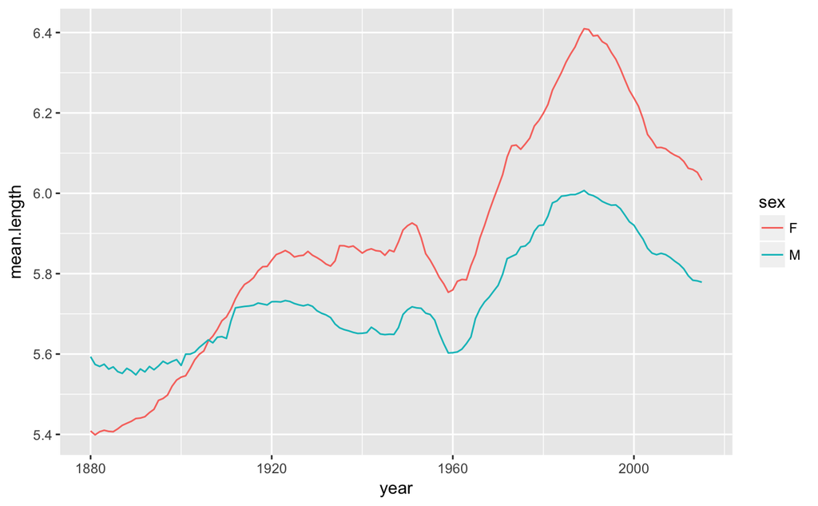

```r
babynames %>%
  group_by(year, sex) %>%
  summarise(mean.length=sum(n*nchar(name))/sum(n)) %>%
  ggplot(aes(x=year, y=mean.length, colour=sex)) + geom_line()
```

Maja’s investigation of Chantal variants

1. testing the regular expression:

```r
babynames$name %>% unique() %>% str_subset("[S|C+]c?+h?+a+n{1,}+t+[a{1,}e{1,}]+l{1,}+e?")
```

```
 [1] "Chantal"   "Chantel"   "Chantell"  "Chantelle" "Shantel"   "Chantele"  "Shantell"  "Shantelle" "Chantale"  "Chantella" "Shantele"  "Shantella"
[13] "Shantal"   "Shantale"  "Chantalle" "Schantel"  "Shantala"  "Chanteal"  "Chantall"  "Shantela"  "Shantall"  "Shanteal"  "Shantalle"
```

Linnea’s Game of Thrones plot. Note the use of `annotate` to put the label onto an independent layer:

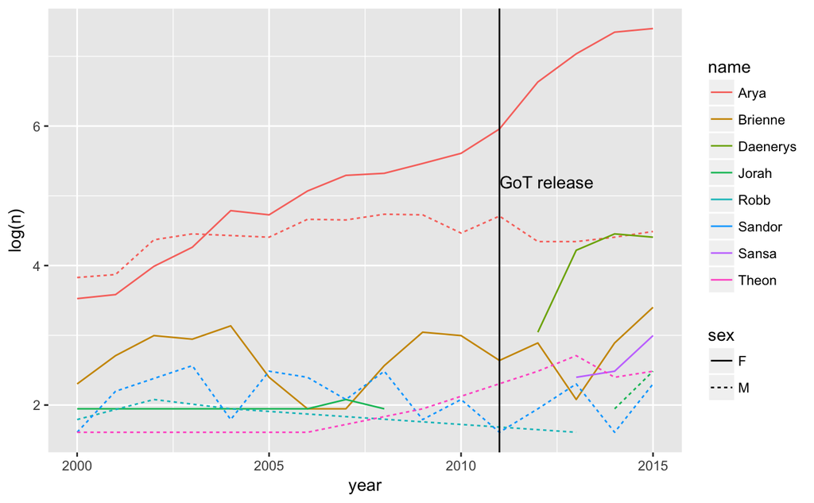

```r
filter(babynames, name=="Daenerys" | name=="Cersei" | name=="Arya" | name=="Sansa" | name=="Margaery" | name=="Ygritte" | name=="Brienne" | name=="Robb" | name=="Theon" | name=="Sandor" | name=="Tormund" | name=="Gendry" | name=="Jorah" | name=="Joffrey")%>% filter(year%in%2000:2015) %>% ggplot(aes(x=year, y=log(n), colour=name, linetype=sex)) + geom_line() + annotate("text", hjust=0, label="GoT release", x=2011, y=5.2) + geom_vline(xintercept=2011)
```

A slight reworking of Marc’s investigation of presidents and spouses. Note - added a `role` columns - the label data is in a independent data frame from the time series/popularity data

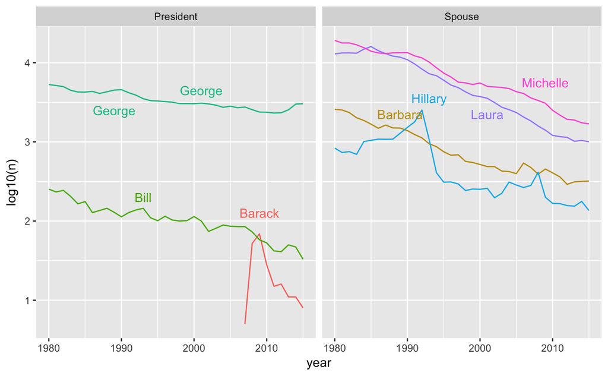

```r
library(babynames)
babynames %>%
  #find out all the boys named George, Bill, and Barack. Find out all the girls named Barbara, Hillary, Laura, and Michelle.
  filter((name %in% c("George","Bill","Barack") & sex=="M")|(name %in% c("Barbara","Hillary","Laura","Michelle") & sex=="F")) %>%
  #only take the observations from 1980 to 2015 (take a bit before 1989 as a buffer).
  filter(year %in% c(1980:2015)) %>%
  mutate(role=if_else(sex=="M", "President", "Spouse")) %>%
  #use geom_text to show the starting point of each first lady in the timeline and sync the colors
  ggplot(aes(x=year, y=log10(n), colour=name)) +
  geom_line() +facet_wrap(~role) -> p
label.data <- tibble(
  name=c("George","Bill","George","Barack","Barbara","Hillary","Laura","Michelle"),
  sex=c("M","M","M","M","F","F","F","F"),
  year=c(1989, 1993, 2001, 2009, 1989, 1993, 2001, 2009),
  y.pos=c(3.4,2.3,3.65,2.1,3.35,3.55,3.35,3.75)
) %>% mutate(role=if_else(sex=="M", "President", "Spouse"))
p + geom_text(data=label.data, aes(x=year, y=y.pos, label=name)) + guides(colour=FALSE)
```

Rima’s look at Hillaries and Monicas, allowing for variant spelling. - `str_extract` to filter out only the rows we’re interested in - `str_sub` to change normalise all the names to “H” and “M” - `recode` to change the “H” and “M” values to something more self-explanatory

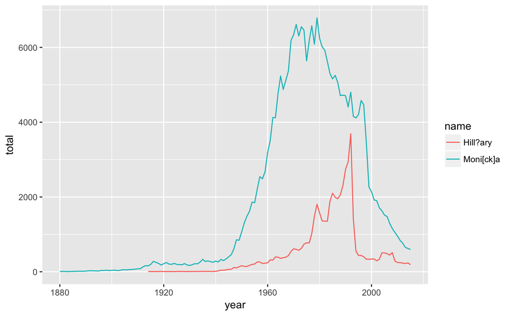

```r
babynames %>%
  filter(name %in% str_extract(name, "Hill?ary|Moni[ck]a")) %>%
  filter(sex=="F") %>%
  mutate(name=str_sub(name, 1, 1)) %>%
  mutate(name=recode(name, H="Hill?ary", M="Moni[ck]a")) %>%
  group_by(year, sex, name) %>%
  summarise(total=sum(n)) %>%
  ggplot(aes(x=year, y=total, colour=name)) + geom_line()
```